# 03_v3_chla_models

Arthur de Grandpré

11 septembre 2020

This is an attempt to make a clear and simple run of the modelling exercise for chlorophyll-a in the Midden-Limburg de Wijers ponds.

The data used here comes from Lvl-1 sentinel2 A and B multispectral imagery.  
It was atmospherically corrected by Nicolas using Acolite  
It was then corrected for adjacency effects using the similarity spectrum method, as adapted from Nicolas’ internship to work within the R ecosystem.

The table below inspects the resulting dataframe.

```
##  [1] "X.1"       "X"         "x"         "y"         "rhos_443"  "rhos_492"
##  [7] "rhos_560"  "rhos_665"  "rhos_704"  "rhos_740"  "rhos_783"  "rhos_833"
## [13] "rhos_865"  "rhos_1614" "rhos_2202" "date"      "satellite" "pond"
## [19] "class"
```

```
##
## =================================================================
## Statistic    N     Mean  St. Dev.  Min   Pctl(25) Pctl(75)  Max
## -----------------------------------------------------------------
## x         297,422 5.333   0.005   5.326   5.329    5.335   5.344
## y         297,422 50.984  0.001   50.982  50.983   50.985  50.987
## b1        297,422 0.485   0.496   -0.537  0.043    0.774   2.420
## b2        297,422 0.467   0.472   -0.557  0.043    0.771   2.226
## b3        297,422 0.462   0.449   -0.556  0.056    0.760   2.104
## b4        297,422 0.455   0.439   -0.575  0.051    0.766   2.026
## b5        297,422 0.479   0.436   -0.576  0.079    0.782   2.014
## b6        297,422 0.516   0.423   -0.595  0.151    0.804   2.017
## b7        297,422 0.521   0.410   -0.599  0.174    0.801   1.996
## b8        297,422 0.528   0.419   -0.634  0.171    0.812   2.040
## bx        297,422 0.525   0.401   -0.606  0.187    0.802   1.965
## b11       297,422 0.288   0.228   -0.355  0.099    0.438   1.294
## b12       297,422 0.326   0.331   -0.286  0.066    0.439   1.821
## -----------------------------------------------------------------
```

We appear have <0 and >1 data, altough most data points appear to be within the 0-1 range.  
Data outside this range is unexpect and abnormal, it should then be excluded, rescaled or reassigned.  
For now, let’s assign low and high values within the 0-1 range. exactly 0 or 1 could cause issues.

```r
acolite[,3:13][acolite[,3:13]<0]=0.005
acolite[,3:13][acolite[,3:13]>1]=0.9
```

Let’s set up the models.

# Chl-a models

We will create multiple models to evaluate their performance.  
First: a linear regression model taking every pixels from every date with matching field data and satellite overpass.  
Second: a linear regression model taking pond mean values from every date with matching field data and satellite overpass.  
Third: a linear regression model taking monthly pond mean values and monthly field average.  
Fourth: The best model will be retested including interaction terms

All spectral bands will be included in the model selector, which rejects bad predictors based on VIF and AIC.  
Spectral ratios will also be included in the predictors, as tested within Nic’s MSc thesis.

a <- b3/b1  
k <- b3/b2 where k replaces b for clarity  
c <- b3/b4  
d <- b5/b4  
e <- b6/b4  
f <- b7/b4  
g <- bx/b4 where bx is band8A  
h <- b8/b4  
i <- (b5+b6)/b4  
j <- b5-((b4+b6)/2)

Ratios and bands from a 60m resolution will not be included

## 1. individual pixels

```r
initial_model = sqrt(chla)~b2+b3+b4+b5+b6+b7+b8+bx+b11+b12+k+c+d+e+f+g+h+i+j
dataset = df

model = model_selector(initial_model, dataset)

fit.allpix=lm(attributes(model)$heading[length(attributes(model)$heading)-1], data=df)
summary(fit.allpix)
```

```
##
## Call:
## lm(formula = attributes(model)$heading[length(attributes(model)$heading) -
##     1], data = df)
##
## Residuals:
##     Min      1Q  Median      3Q     Max
## -10.005  -2.533  -1.056   2.530   9.442
##
## Coefficients:
##             Estimate Std. Error t value Pr(>|t|)
## (Intercept)  6.72122    0.05375 125.055  < 2e-16 ***
## b2          -1.34796    0.19315  -6.979 3.08e-12 ***
## b12          0.43934    0.29795   1.475     0.14
## k            0.12097    0.01824   6.633 3.39e-11 ***
## j           35.73289    1.22802  29.098  < 2e-16 ***
## ---
## Signif. codes:  0 '***' 0.001 '**' 0.01 '*' 0.05 '.' 0.1 ' ' 1
##
## Residual standard error: 3.054 on 18271 degrees of freedom
## Multiple R-squared:  0.04918,    Adjusted R-squared:  0.04897
## F-statistic: 236.3 on 4 and 18271 DF,  p-value: < 2.2e-16
```

```r
options(na.action=na.fail)
d=(dredge(fit.allpix))
head(d)
```

```
## Global model call: lm(formula = attributes(model)$heading[length(attributes(model)$heading) -
##     1], data = df)
## ---
## Model selection table
##    (Intrc)     b12     b2     j      k df    logLik    AICc delta weight
## 16   6.721  0.4393 -1.348 35.73 0.1210  6 -46336.53 92685.1  0.00  0.522
## 15   6.742         -1.104 35.59 0.1184  5 -46337.61 92685.2  0.17  0.478
## 7    6.969         -1.300 35.83         4 -46358.86 92725.7 40.66  0.000
## 8    6.960  0.2512 -1.443 35.91         5 -46358.50 92727.0 41.95  0.000
## 14   6.689 -1.3440        34.07 0.1304  5 -46360.85 92731.7 46.65  0.000
## 6    6.945 -1.6840        34.14         4 -46386.44 92780.9 95.83  0.000
## Models ranked by AICc(x)
```

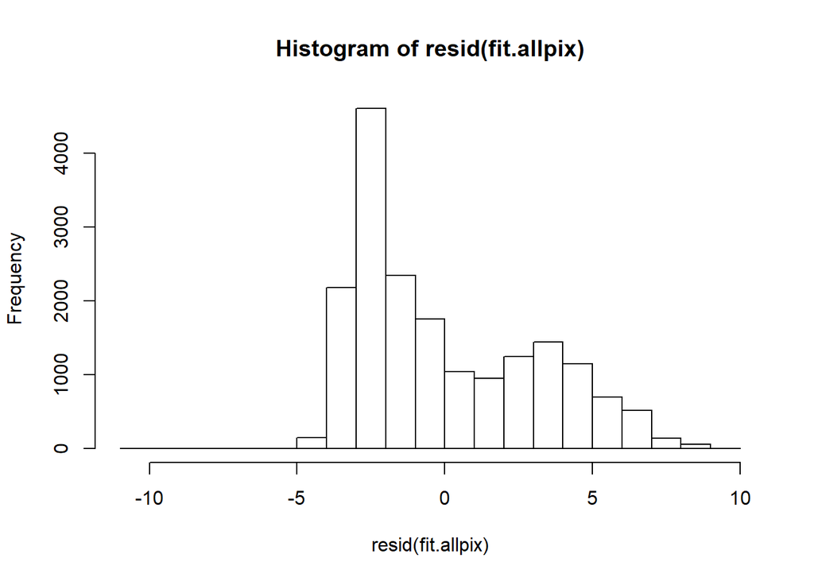

```r
options(na.action=na.omit)

# plot(fit.allpix)
hist(resid(fit.allpix))
```

```r
sqrt(mean(fit.allpix$residuals^2)) # RMSE
```

```
## [1] 3.053954
```

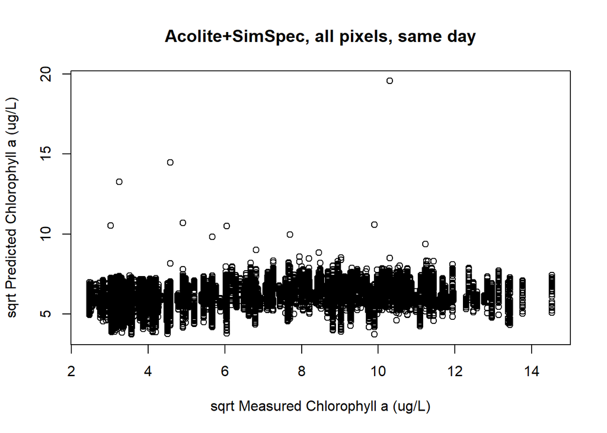

```r
df$chla.p = predict(fit.allpix, new.data=df)

plot(df$chla.p~sqrt(df$chla),
     main="Acolite+SimSpec, all pixels, same day",
     xlab="sqrt Measured Chlorophyll a (ug/L)",
     ylab="sqrt Predicted Chlorophyll a (ug/L)")
```

## 2. pond mean

```r
initial_model=sqrt(chla)~b2+b3+b4+b5+b6+b7+b8+bx+b11+b12+k+c+d+e+f+g+h+i+j
dataset=df

model=model_selector(initial_model, dataset)

fit.meanp=lm(attributes(model)$heading[length(attributes(model)$heading)-1], data=df)
summary(fit.meanp)
```

```
##
## Call:
## lm(formula = attributes(model)$heading[length(attributes(model)$heading) -
##     1], data = df)
##
## Residuals:
##    Min     1Q Median     3Q    Max
## -5.031 -1.820 -0.274  2.009  6.311
##
## Coefficients:
##              Estimate Std. Error t value Pr(>|t|)
## (Intercept)    4.3648     1.0700   4.079 8.33e-05 ***
## b2          -110.1925    57.5689  -1.914  0.05807 .
## b6            47.0067    19.7511   2.380  0.01895 *
## h              0.7752     0.2799   2.769  0.00654 **
## j            190.6070    30.6467   6.219 8.14e-09 ***
## ---
## Signif. codes:  0 '***' 0.001 '**' 0.01 '*' 0.05 '.' 0.1 ' ' 1
##
## Residual standard error: 2.616 on 116 degrees of freedom
## Multiple R-squared:  0.3443, Adjusted R-squared:  0.3217
## F-statistic: 15.23 on 4 and 116 DF,  p-value: 4.889e-10
```

```r
options(na.action=na.fail)
d=(dredge(fit.meanp))
```

```
## Fixed term is "(Intercept)"
```

```r
head(d)
```

```
## Global model call: lm(formula = attributes(model)$heading[length(attributes(model)$heading) -
##     1], data = df)
## ---
## Model selection table
##    (Intrc)      b2    b6      h     j df   logLik  AICc delta weight
## 16   4.365 -110.20 47.01 0.7752 190.6  6 -285.484 583.7  0.00  0.464
## 15   3.246         21.56 1.0760 203.4  5 -287.365 585.3  1.55  0.214
## 13   4.156               1.1050 196.7  4 -288.457 585.3  1.55  0.214
## 14   4.513  -17.98       1.0620 193.3  5 -288.368 587.3  3.55  0.079
## 12   6.524 -199.70 70.56        165.0  5 -289.357 589.2  5.53  0.029
## 10   8.269  -90.85              152.4  4 -296.573 601.5 17.79  0.000
## Models ranked by AICc(x)
```

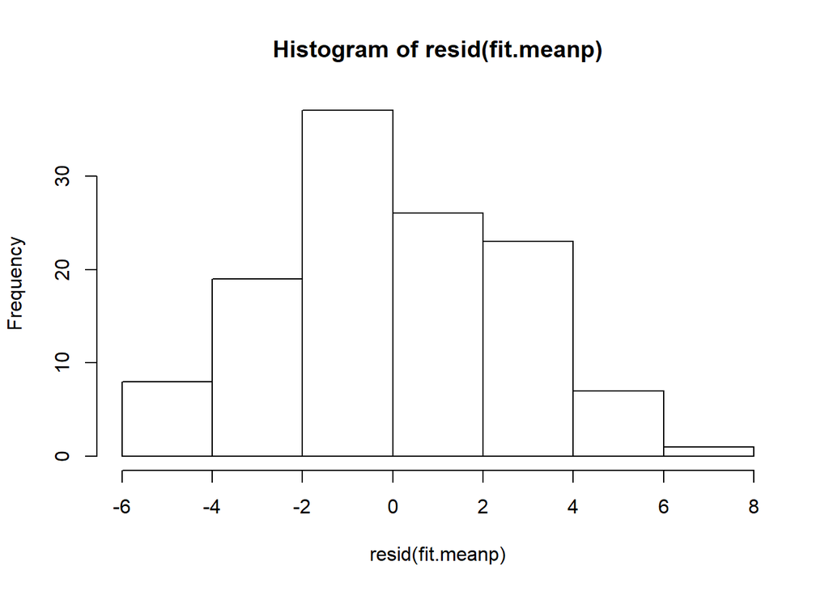

```r
options(na.action=na.omit)

# summary(fit.meanp)
# plot(fit.meanp)
hist(resid(fit.meanp))
```

```r
sqrt(mean(fit.meanp$residuals^2))
```

```
## [1] 2.561083
```

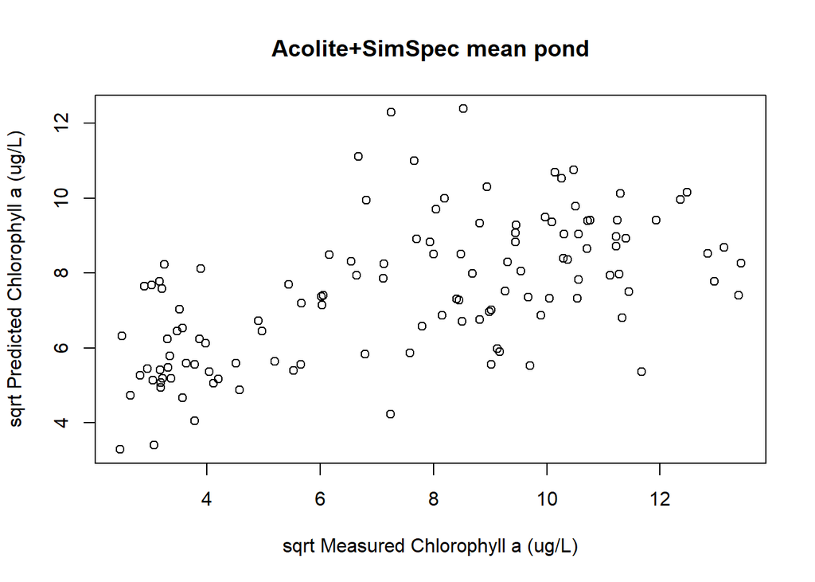

```r
df$chla.p = predict(fit.meanp, new.data=df)

plot(df$chla.p~sqrt(df$chla),
     main="Acolite+SimSpec mean pond",
     xlab="sqrt Measured Chlorophyll a (ug/L)",
     ylab="sqrt Predicted Chlorophyll a (ug/L)")
```

## 3. monthly pond mean

```r
initial_model=sqrt(chla)~b2+b3+b4+b5+b6+b7+b8+bx+b11+b12+k+c+d+e+f+g+h+i+j
dataset=df

model=model_selector(initial_model, dataset)

fit.monthly=lm(attributes(model)$heading[length(attributes(model)$heading)-1], data=df, y=T, x=T)
summary(fit.monthly)
```

```
##
## Call:
## lm(formula = attributes(model)$heading[length(attributes(model)$heading) -
##     1], data = df, x = T, y = T)
##
## Residuals:
##     Min      1Q  Median      3Q     Max
## -3.9054 -1.8896 -0.0815  2.0108  4.9802
##
## Coefficients:
##              Estimate Std. Error t value Pr(>|t|)
## (Intercept)    5.2164     1.9603   2.661   0.0106 *
## b2          -169.3713    99.5439  -1.701   0.0953 .
## b11           60.9510    34.6654   1.758   0.0851 .
## h              1.0679     0.5207   2.051   0.0458 *
## j            226.7633    44.2440   5.125 5.25e-06 ***
## ---
## Signif. codes:  0 '***' 0.001 '**' 0.01 '*' 0.05 '.' 0.1 ' ' 1
##
## Residual standard error: 2.378 on 48 degrees of freedom
## Multiple R-squared:  0.4432, Adjusted R-squared:  0.3968
## F-statistic: 9.552 on 4 and 48 DF,  p-value: 9.174e-06
```

```r
options(na.action=na.fail)
d=(dredge(fit.monthly))
```

```
## Fixed term is "(Intercept)"
```

```r
head(d)
```

```
## Global model call: lm(formula = attributes(model)$heading[length(attributes(model)$heading) -
##     1], data = df, x = T, y = T)
## ---
## Model selection table
##    (Intrc)   b11      b2     h     j df   logLik  AICc delta weight
## 13   3.243               1.523 221.2  4 -120.372 249.6  0.00  0.390
## 16   5.216 60.95 -169.40 1.068 226.8  6 -118.483 250.8  1.22  0.212
## 14   2.742 20.24         1.526 233.8  5 -120.035 251.3  1.77  0.161
## 15   4.241        -48.56 1.391 212.0  5 -120.137 251.6  1.97  0.145
## 12   8.706 86.01 -274.90       208.1  5 -120.709 252.7  3.12  0.082
## 11   8.835       -131.70       175.2  4 -124.056 256.9  7.37  0.010
## Models ranked by AICc(x)
```

```r
options(na.action=na.omit)
```

we seem to obtain two equivalent models, one with 4 predictors and the other with 2. Let’s look at the 4 predictors first.

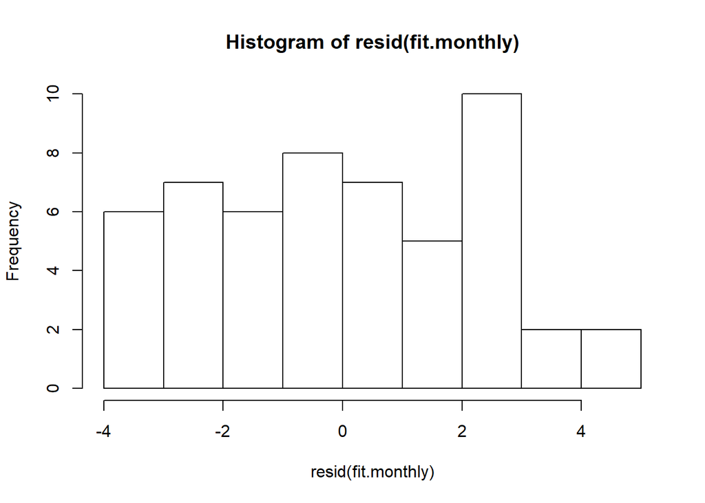

```r
hist(resid(fit.monthly))
```

```r
sqrt(mean(fit.monthly$residuals^2))
```

```
## [1] 2.262776
```

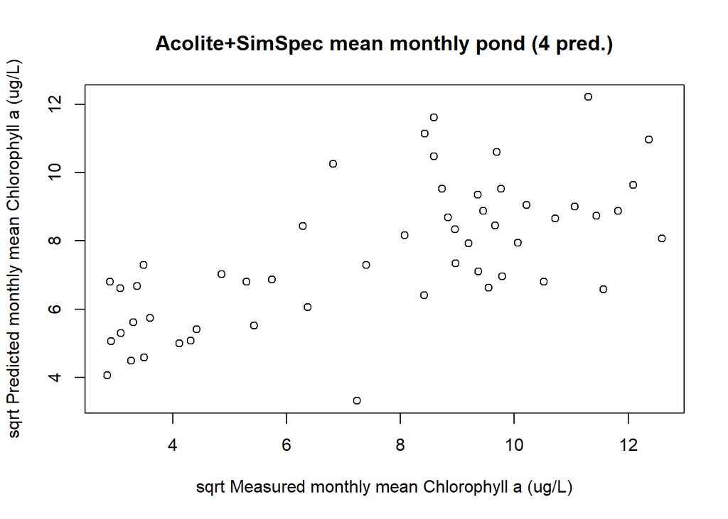

```r
df$chla.p = predict(fit.monthly, new.data=df)

plot(df$chla.p~sqrt(df$chla),
     main="Acolite+SimSpec mean monthly pond (4 pred.)",
     xlab="sqrt Measured monthly mean Chlorophyll a (ug/L)",
     ylab="sqrt Predicted monthly mean Chlorophyll a (ug/L)")
```

now the 2 predictors

```r
fit.monthly2=lm(sqrt(chla)~h+j,data=df,x=T,y=T)
summary(fit.monthly2)
```

```
##
## Call:
## lm(formula = sqrt(chla) ~ h + j, data = df, x = T, y = T)
##
## Residuals:
##     Min      1Q  Median      3Q     Max
## -4.3991 -1.8251 -0.0779  1.8682  5.2433
##
## Coefficients:
##             Estimate Std. Error t value Pr(>|t|)
## (Intercept)   3.2430     1.1766   2.756  0.00814 **
## h             1.5233     0.4525   3.367  0.00147 **
## j           221.2164    41.8483   5.286 2.75e-06 ***
## ---
## Signif. codes:  0 '***' 0.001 '**' 0.01 '*' 0.05 '.' 0.1 ' ' 1
##
## Residual standard error: 2.414 on 50 degrees of freedom
## Multiple R-squared:  0.4021, Adjusted R-squared:  0.3782
## F-statistic: 16.81 on 2 and 50 DF,  p-value: 2.608e-06
```

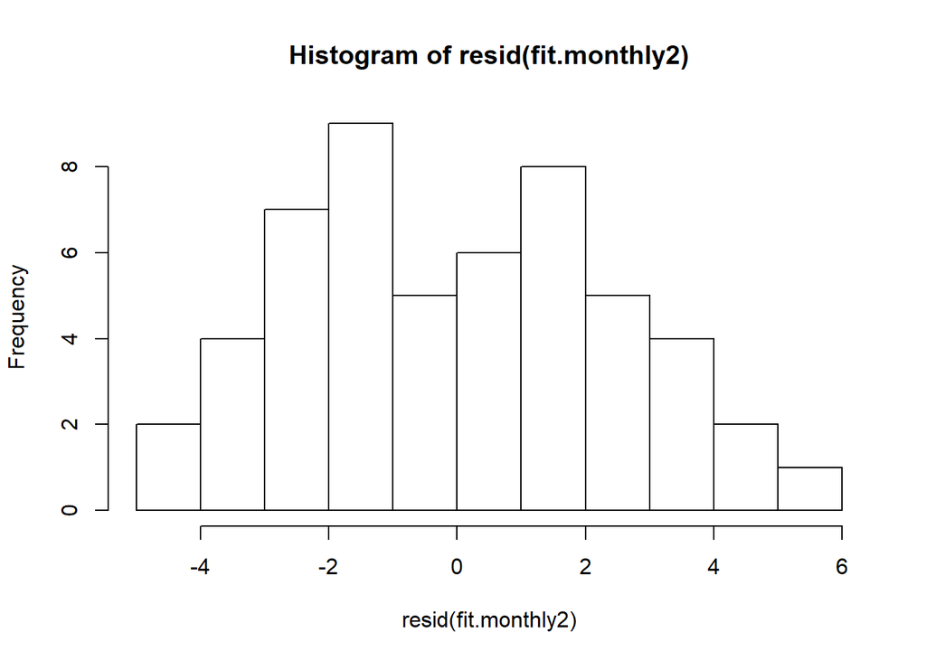

```r
# plot(fit.monthly2)
hist(resid(fit.monthly2))
```

```r
sqrt(mean(fit.monthly2$residuals^2))
```

```
## [1] 2.34487
```

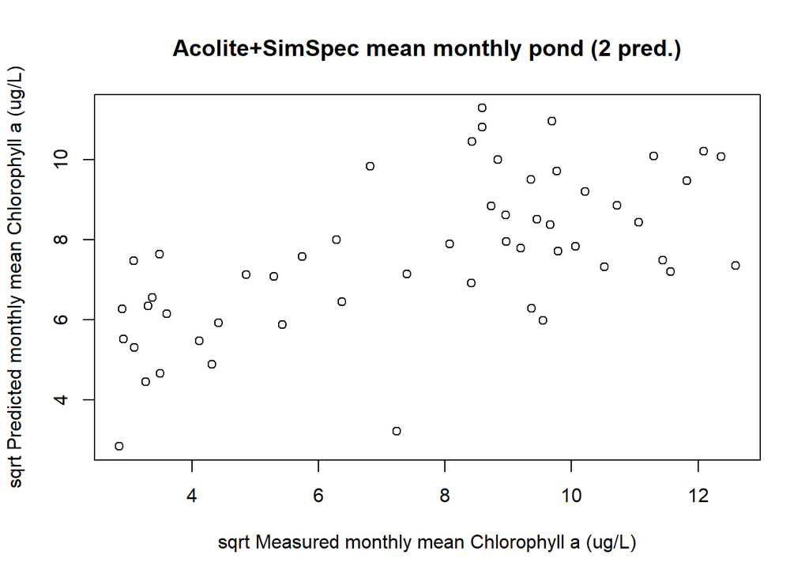

```r
df$chla.p2 = predict(fit.monthly2, new.data=df)

plot(df$chla.p2~sqrt(df$chla),
     main="Acolite+SimSpec mean monthly pond (2 pred.)",
     xlab="sqrt Measured monthly mean Chlorophyll a (ug/L)",
     ylab="sqrt Predicted monthly mean Chlorophyll a (ug/L)")
```

In both models, one point appears to be especially badly predicted. let’s remove it.

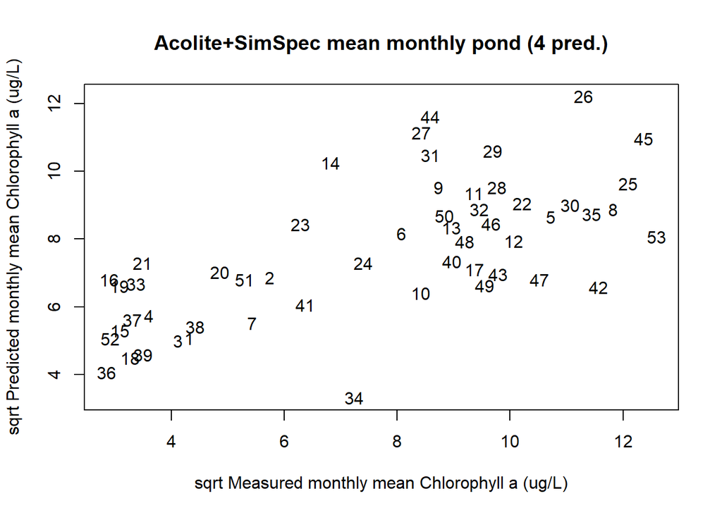

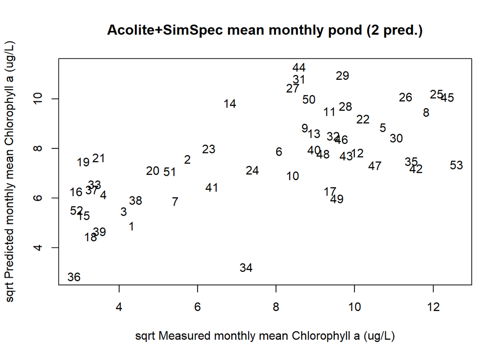

```r
dfs = df[-34,]

initial_model=sqrt(chla)~b2+b3+b4+b5+b6+b7+b8+bx+b11+b12+k+c+d+e+f+g+h+i+j
dataset=dfs

model=model_selector(initial_model, dataset)

fit.monthly.s=lm(attributes(model)$heading[length(attributes(model)$heading)-1], data=dfs, y=T, x=T)
summary(fit.monthly.s)
```

```
##
## Call:
## lm(formula = attributes(model)$heading[length(attributes(model)$heading) -
##     1], data = dfs, x = T, y = T)
##
## Residuals:
##     Min      1Q  Median      3Q     Max
## -4.2536 -1.3349 -0.0635  1.0929  4.0743
##
## Coefficients:
##              Estimate Std. Error t value Pr(>|t|)
## (Intercept)    5.0383     1.5786   3.192 0.002551 **
## b8          -200.9054    49.4623  -4.062 0.000188 ***
## b11          116.8627    30.0220   3.893 0.000318 ***
## c             -2.4695     0.6528  -3.783 0.000446 ***
## h              3.9540     0.6299   6.277 1.11e-07 ***
## j            416.5850    55.1411   7.555 1.35e-09 ***
## ---
## Signif. codes:  0 '***' 0.001 '**' 0.01 '*' 0.05 '.' 0.1 ' ' 1
##
## Residual standard error: 2.017 on 46 degrees of freedom
## Multiple R-squared:  0.6158, Adjusted R-squared:  0.5741
## F-statistic: 14.75 on 5 and 46 DF,  p-value: 1.254e-08
```

```r
options(na.action=na.fail)
d=(dredge(fit.monthly.s))
```

```
## Fixed term is "(Intercept)"
```

```r
head(d)
```

```
## Global model call: lm(formula = attributes(model)$heading[length(attributes(model)$heading) -
##     1], data = dfs, x = T, y = T)
## ---
## Model selection table
##    (Intrc)    b11      b8       c     h     j df   logLik  AICc delta weight
## 32   5.038 116.90 -200.90 -2.4690 3.954 416.6  7 -107.087 230.7  0.00  0.987
## 28   1.981  63.46  -69.75         2.245 269.3  6 -114.130 242.1 11.41  0.003
## 25   2.160                        1.912 235.9  4 -116.725 242.3 11.58  0.003
## 26   1.120  34.18                 1.987 259.8  5 -115.763 242.8 12.11  0.002
## 31   4.628         -69.73 -1.2750 2.740 292.5  6 -114.489 242.8 12.13  0.002
## 29   2.510                -0.6212 2.221 268.8  5 -116.020 243.3 12.63  0.002
## Models ranked by AICc(x)
```

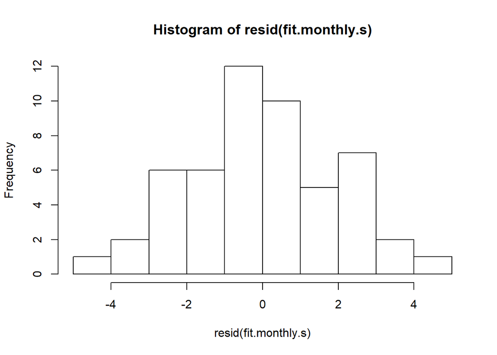

```r
options(na.action=na.omit)

hist(resid(fit.monthly.s))
```

```r
sqrt(mean(fit.monthly.s$residuals^2))
```

```
## [1] 1.897279
```

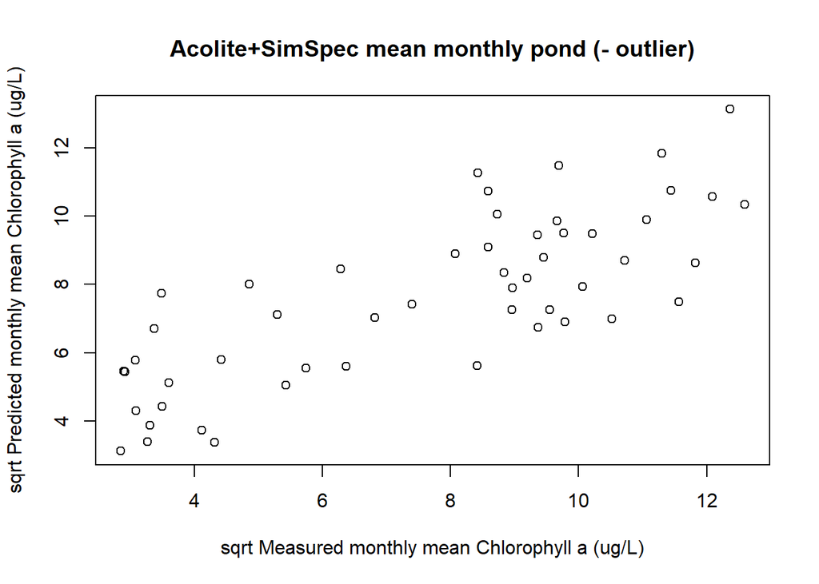

```r
dfs$chla.ps = predict(fit.monthly.s, newdata=dfs)

plot(dfs$chla.ps~sqrt(dfs$chla),
     main="Acolite+SimSpec mean monthly pond (- outlier)",
     xlab="sqrt Measured monthly mean Chlorophyll a (ug/L)",
     ylab="sqrt Predicted monthly mean Chlorophyll a (ug/L)")
```

In case the model isn’t completely linear, let’s try it with polynomial terms

```r
fit.monthly.poly=lm(sqrt(chla)~poly(b11,2)+poly(b8,2)+poly(c,2)+poly(h,2)+poly(j,2), data=df, y=T, x=T)
summary(fit.monthly.poly)
```

```
##
## Call:
## lm(formula = sqrt(chla) ~ poly(b11, 2) + poly(b8, 2) + poly(c,
##     2) + poly(h, 2) + poly(j, 2), data = df, x = T, y = T)
##
## Residuals:
##     Min      1Q  Median      3Q     Max
## -4.0590 -1.0869  0.0763  0.9867  3.8082
##
## Coefficients:
##               Estimate Std. Error t value Pr(>|t|)
## (Intercept)     7.6007     0.2613  29.087  < 2e-16 ***
## poly(b11, 2)1  11.3276     3.1623   3.582 0.000879 ***
## poly(b11, 2)2  -1.9114     2.5841  -0.740 0.463593
## poly(b8, 2)1  -12.3082     4.5885  -2.682 0.010407 *
## poly(b8, 2)2    1.4699     3.5527   0.414 0.681173
## poly(c, 2)1   -12.8307     5.0115  -2.560 0.014145 *
## poly(c, 2)2    -3.6045     3.0590  -1.178 0.245304
## poly(h, 2)1    16.0335     5.0540   3.172 0.002825 **
## poly(h, 2)2     6.6540     2.7608   2.410 0.020404 *
## poly(j, 2)1    21.7853     4.5541   4.784 2.14e-05 ***
## poly(j, 2)2    -6.3146     2.3957  -2.636 0.011711 *
## ---
## Signif. codes:  0 '***' 0.001 '**' 0.01 '*' 0.05 '.' 0.1 ' ' 1
##
## Residual standard error: 1.902 on 42 degrees of freedom
## Multiple R-squared:  0.6881, Adjusted R-squared:  0.6139
## F-statistic: 9.267 on 10 and 42 DF,  p-value: 7.292e-08
```

```r
options(na.action=na.fail)
d=(dredge(fit.monthly.poly))
```

```
## Fixed term is "(Intercept)"
```

```r
head(d)
```

```
## Global model call: lm(formula = sqrt(chla) ~ poly(b11, 2) + poly(b8, 2) + poly(c,
##     2) + poly(h, 2) + poly(j, 2), data = df, x = T, y = T)
## ---
## Model selection table
##    (Int) ply(b11,2) ply(b8,2) ply(c,2) ply(h,2) ply(j,2) df   logLik  AICc
## 32 7.601          +         +        +        +        + 12 -103.124 238.0
## 30 7.601          +                  +        +        + 10 -107.413 240.1
## 29 7.601                             +        +        +  8 -111.514 242.3
## 31 7.601                    +        +        +        + 10 -111.287 247.8
## 25 7.601                                      +        +  6 -117.350 248.5
## 26 7.601          +                           +        +  8 -114.720 248.7
##    delta weight
## 32  0.00  0.666
## 30  2.02  0.243
## 29  4.25  0.079
## 31  9.77  0.005
## 25 10.48  0.004
## 26 10.67  0.003
## Models ranked by AICc(x)
```

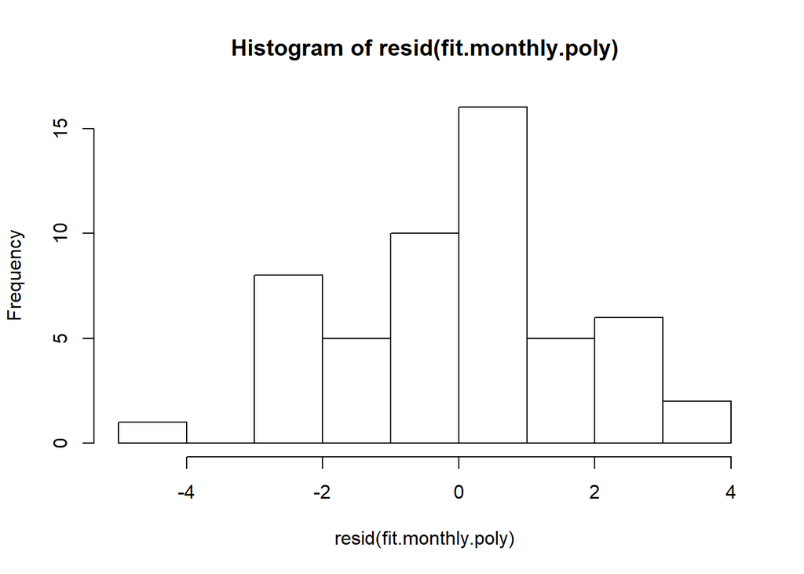

```r
options(na.action=na.omit)

# plot(fit.monthly.poly)
hist(resid(fit.monthly.poly))
```

```r
sqrt(mean(fit.monthly.poly$residuals^2))
```

```
## [1] 1.693498
```

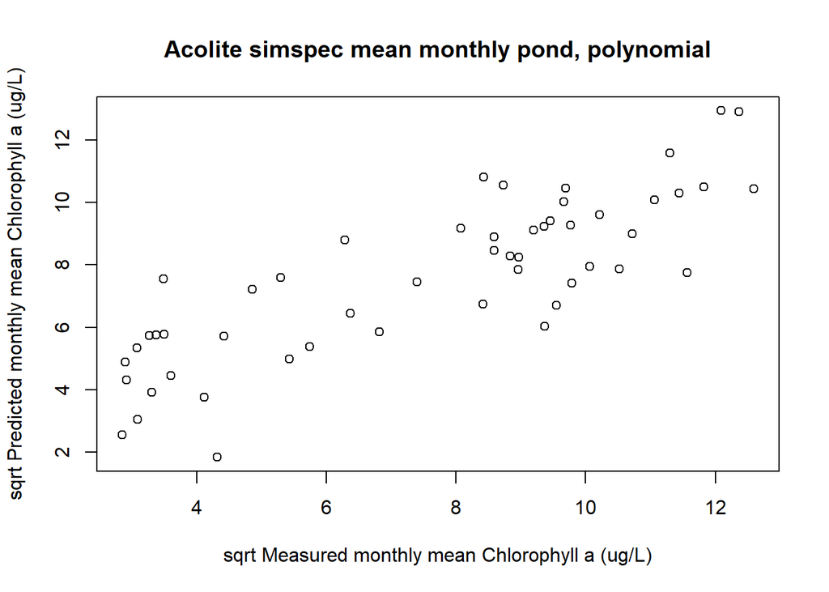

```r
dfs$chla.pc = predict(fit.monthly.poly, newdata=dfs)

plot(dfs$chla.pc~sqrt(dfs$chla),
     main="Acolite simspec mean monthly pond, polynomial",
     xlab="sqrt Measured monthly mean Chlorophyll a (ug/L)",
     ylab="sqrt Predicted monthly mean Chlorophyll a (ug/L)")
```

## 4. Best model + interactions

(Current best models contains too many predictors, hence there are not enough degrees of freedom to add interaction terms. They usually result in massive overfitting anyways.)

# K-folds validation for overfitting

Let’s look only into the models based on monthly means and run a 100 iterations of every model at every k-folds number between 2 and 10. this will allow to see which models are most vulnerable to subsampling.

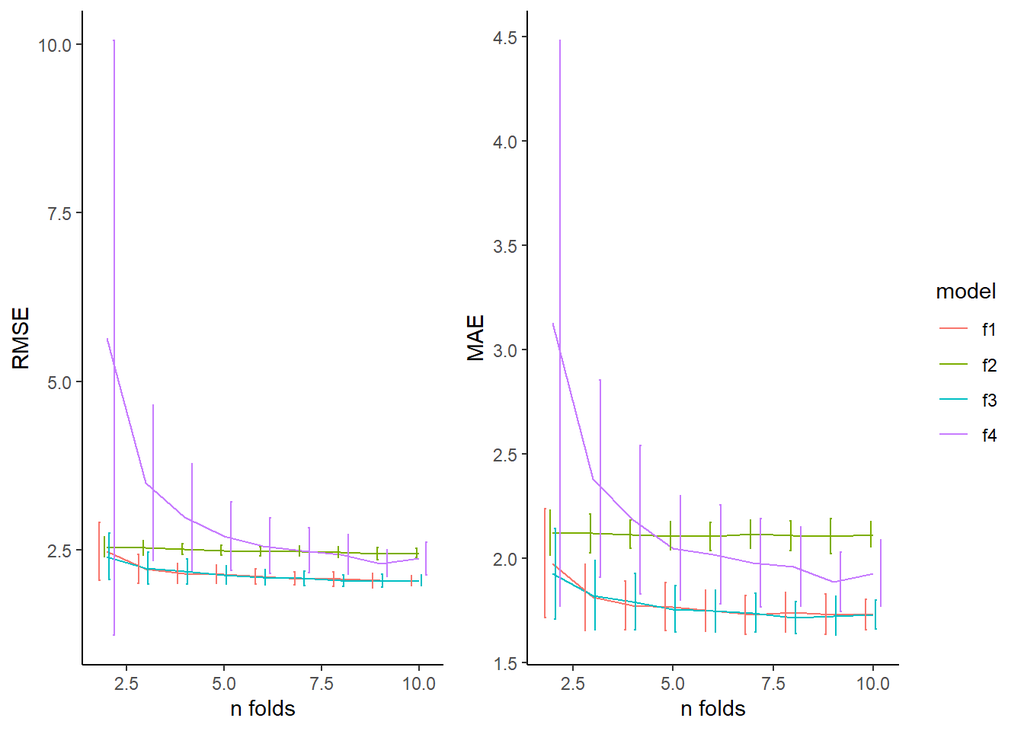

f1 and f3 appear to be roughly equivalent according to the k-folds validation. f3 being the outlier corrected model, it’s reported fit should be much better.

# Chl-a retrieval model

## Model summary

Let’s go back to f3, the monthly average model with a single removed outlier.

```
##
## Call:
## lm(formula = attributes(model)$heading[length(attributes(model)$heading) -
##     1], data = dfs, x = T, y = T)
##
## Residuals:
##     Min      1Q  Median      3Q     Max
## -4.2536 -1.3349 -0.0635  1.0929  4.0743
##
## Coefficients:
##              Estimate Std. Error t value Pr(>|t|)
## (Intercept)    5.0383     1.5786   3.192 0.002551 **
## b8          -200.9054    49.4623  -4.062 0.000188 ***
## b11          116.8627    30.0220   3.893 0.000318 ***
## c             -2.4695     0.6528  -3.783 0.000446 ***
## h              3.9540     0.6299   6.277 1.11e-07 ***
## j            416.5850    55.1411   7.555 1.35e-09 ***
## ---
## Signif. codes:  0 '***' 0.001 '**' 0.01 '*' 0.05 '.' 0.1 ' ' 1
##
## Residual standard error: 2.017 on 46 degrees of freedom
## Multiple R-squared:  0.6158, Adjusted R-squared:  0.5741
## F-statistic: 14.75 on 5 and 46 DF,  p-value: 1.254e-08
```

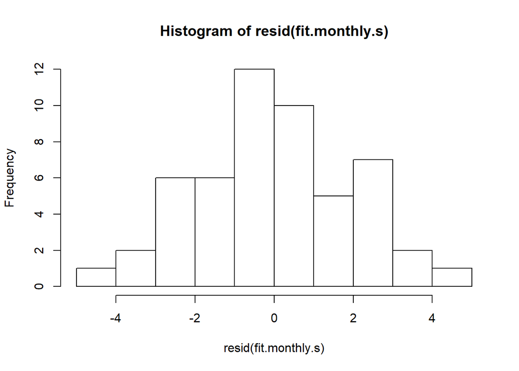

[figure not shown]

[figure not shown]

## Model performance

Let’s look more closely into the model’s performance, for each ponds and pond category.

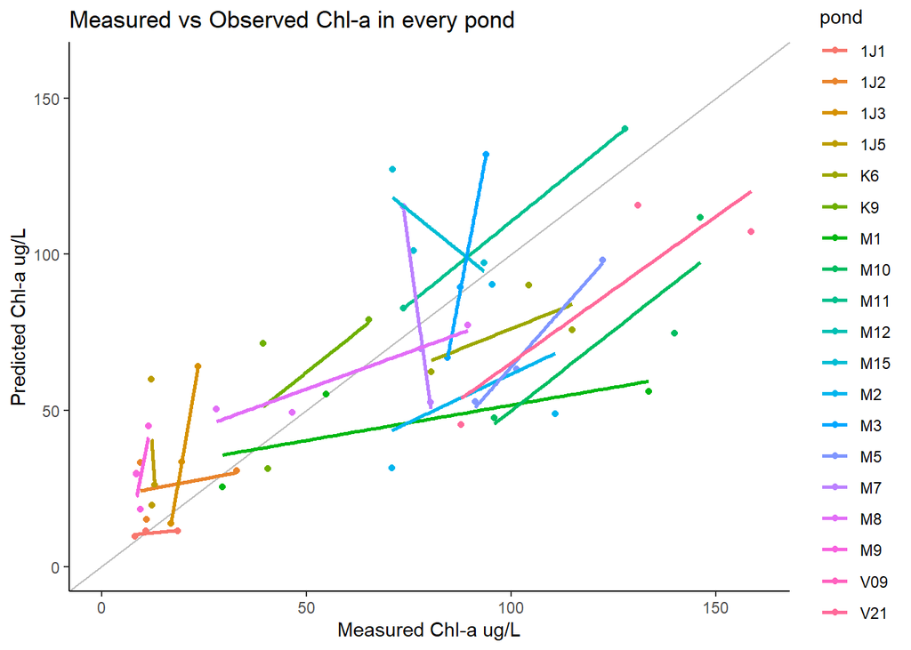

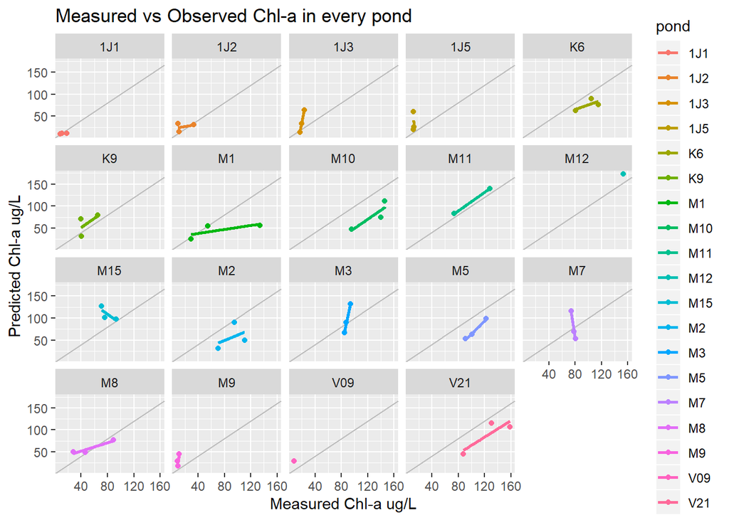

Individually, it seems like some ponds are having trouble being predicted correctly, such as 1J5 and M15. 1J5 is categorized as a low chlorophyll and high macrophyte density pond, which is excepted to be hard to predict. M15 should be a high chlorophyll and low macrophyte density pond. I am unsure why it behaves this way.

M12 and V9 also don’t have enough data points for their performance to be assessed.

Let’s do the same exercice directly with categories

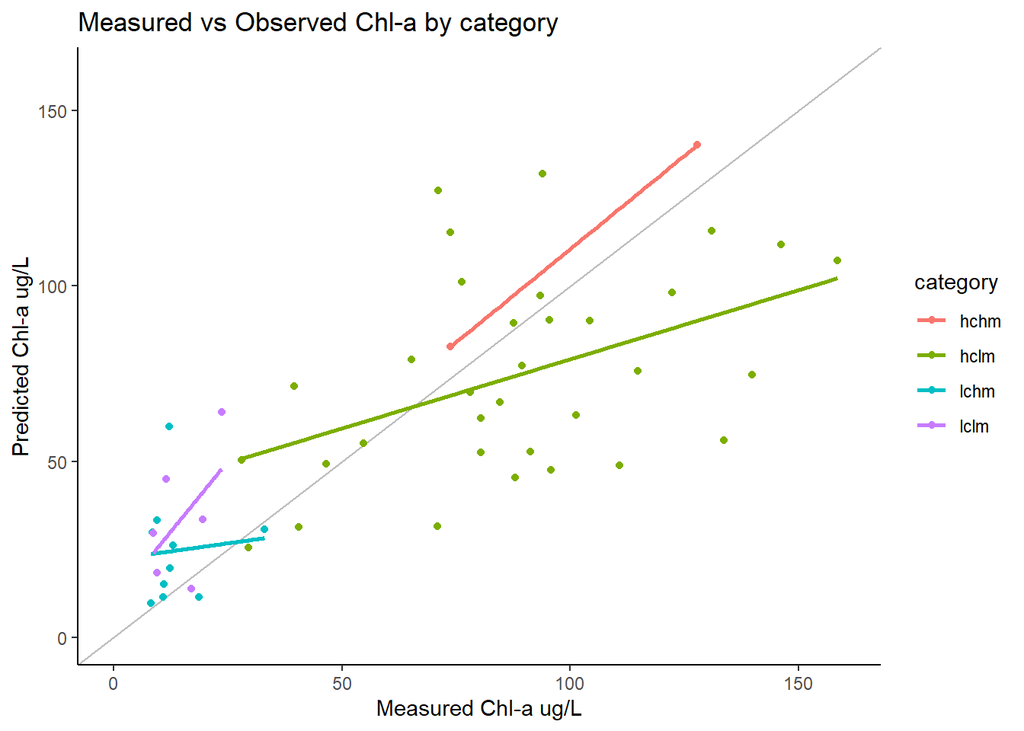

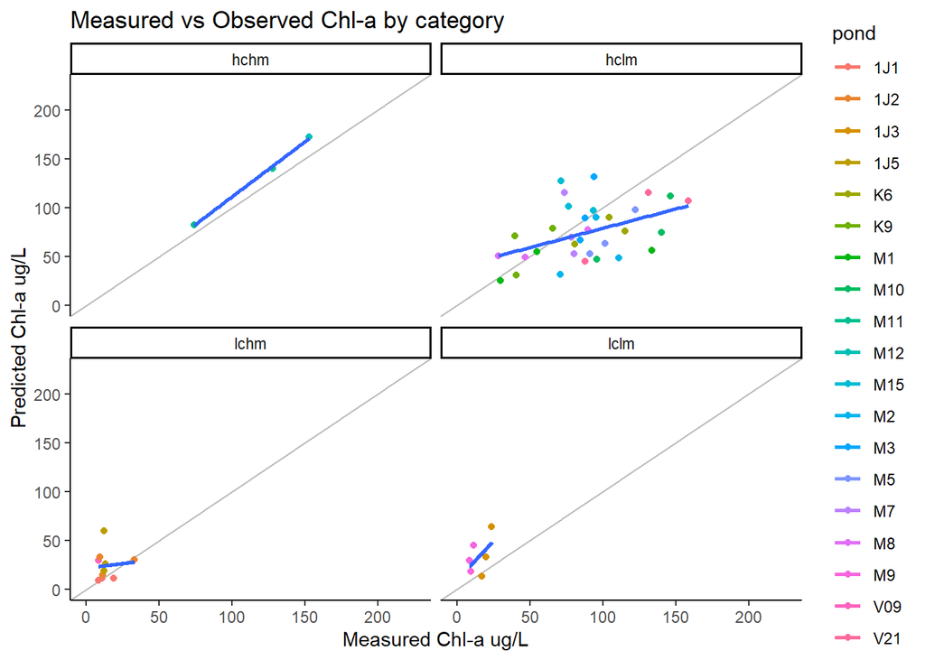

We see that the categories are very badly distributed, with much more data within the HCLM category than the others. We also have very little data about the HCHM category. This category contains M11, M12, V16 and V17. All of those are small ponds, so small even that no “pure” water pixels were kept for V16 and V17, and both M ponds are marked for “floating” vegetation.

In the case of the other categories, as expected LCHM seems to be the hardest to evaluate. low chlorophyll contents are hard to detect as other features are more susceptible to be included in the pixel. It is also harder in the case of high macrophytes, as this can reduces available data in the case of emerging vegetation, or corrupt the specral signature, in the case of submerged vegetation.

# Model application

Let’s apply the model to individual pixels and to ponds.  
Pixels identified as emergent vegetation will be classified as such.

## all pixels

### summer

let’s select a date in july 2015

```
##     Min.  1st Qu.   Median     Mean  3rd Qu.     Max.
##     0.00    11.24    36.08   181.32   117.06 90780.29
```

[interactive chart not shown]

### winter

Let’s select a date in january 2016

```
##     Min.  1st Qu.   Median     Mean  3rd Qu.     Max.
##     0.00    86.69  1035.37  2019.60  3188.22 10814.75
```

[interactive chart not shown]

# Seasonnal trends

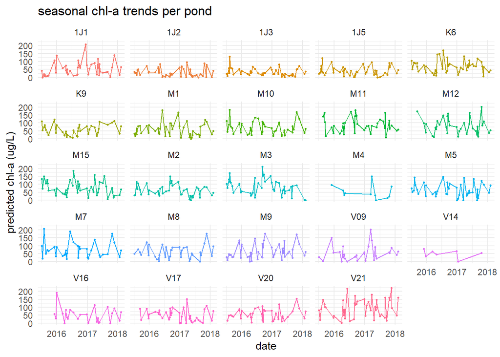

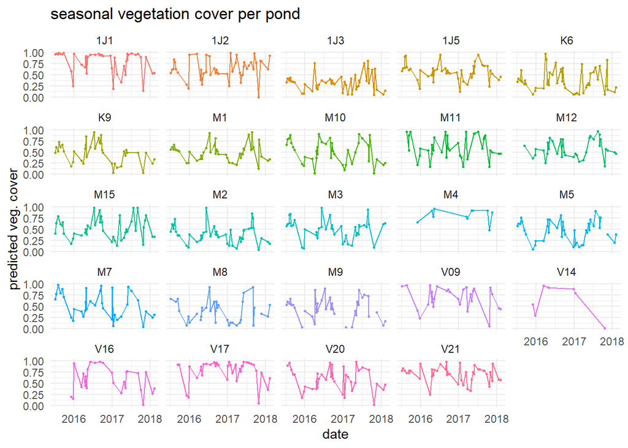